# Uniform Distribution

Eugene Politov

October 21, 2016

# Равномерное распределение

### Probability density function

### Функция распределения

Suppose $f(x)$ is the PDF of a continuous uniform distribution on the interval $[a,b]$. Since a uniform distribution requires that each value of the random variable be equally likely, $f(x)$ will be a constant function. Therefore, suppose $f(x)=c$ on the interval $[a,b]$. Since the definite integral of the PDF over the interval must be equal to 1, we can solve the equation $\int_a^b c \, \mathrm{d}x = 1$ for $c$. Working with the integral, we have

$\int_a^b c \, \mathrm{d}x = \left. cx \right|_a^b = c(b-a) = 1$ which gives $c = \dfrac{1}{b-a}$

In other words, the PDF is $f(a ≤ x ≤ b) = \frac{1}{b-a}$

### Cumulative distribution function

The CDF is simply the integral of the PDF.

$\int_a^x \dfrac{1}{b-a} \mathrm{d}t = \left. \dfrac{1}{b-a} t \right|_a^x = \dfrac{x-a}{b-a}$

$F(x)=\dfrac{x-a}{b-a}$

### Moments

#### Математическое ожидание

$E(X) = \int_a^b \dfrac{1}{b-a} x \, \mathrm{d}x = \left. \dfrac{1}{2(b-a)} x^2 \right|_a^b = \dfrac{b^2-a^2}{2(b-a)} = \dfrac{(b-a)(b+a)}{2(b-a)} = \dfrac{a+b}{2}$

$E(X) = \dfrac{a+b}{2}$

#### Дисперсия

$Var(X) = E(X^2) - (E(X))^2$

$E(X^2) = \int_a^b \dfrac{1}{b-a} x^2 \mathrm{d}x =\left. \dfrac{1}{3(b-a)} x^3 \right|_a^b = \dfrac{b^3-a^3}{3(b-a)} = \dfrac{(b-a)(b^2+ab+a^2)}{3(b-a)} = \dfrac{b^2+ab+a^2}{3}$

$(E(X))^2 = \left(\dfrac{a+b}{2}\right)^2$

$Var(X) = \dfrac{b^2+ab+a^2}{3} - \left( \dfrac{a+b}{2} \right)^2 =$

$=\dfrac{b^2+ab+a^2}{3} - \dfrac{a^2+2ab+b^2}{4} =$

$=\dfrac{4(b^2+ab+a^2)}{12} - \dfrac{3(a^2+2ab+b^2)}{12} =$

$=\dfrac{4a^2+4ab+4b^2-3a^2-6ab-3b^2}{12} =$

$=\dfrac{a^2-2ab+b^2}{12}=\dfrac{b^2-2ab+a^2}{12} =$

$=\dfrac{(b-a)^2}{12}$

$Var(X) = \dfrac{(b-a)^2}{12}$

#### Standard Deviation

$\sigma_X = \dfrac{b-a}{\sqrt{12}}$

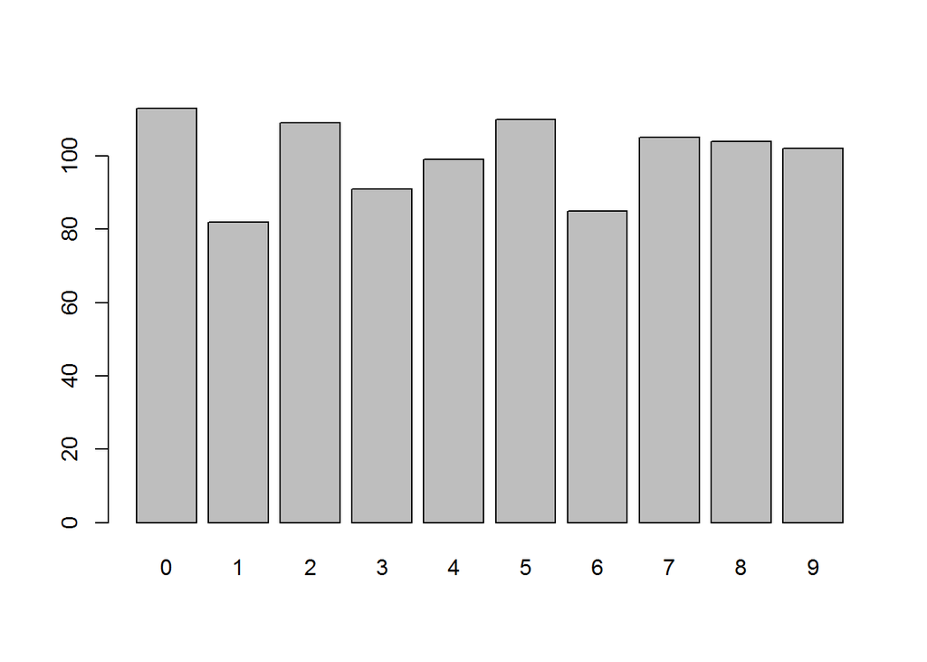

```r
#dunif(x, min = 0, max = 1, log = FALSE)
#punif(q, min = 0, max = 1, lower.tail = TRUE, log.p = FALSE)
#qunif(p, min = 0, max = 1, lower.tail = TRUE, log.p = FALSE)
#runif(n, min = 0, max = 1)
n <- floor(runif(1000)*10)
t <- table(n)
barplot(t)
```